# edgeR Analysis

Vida Talebian

2026-10-21

#### Load packages and data

Load the necessary packages, they are installed and ready to use. On your own environment you might need to install them for the first time.

```r
library(edgeR)
```

```r
library(ggplot2)
library(ggrepel)
library(DT)
```

```r
# work in your workspace directory
setwd("~/workspace/Module6/expression/")

count_file <- "expression_data.txt"
metadata_file <- "sample_metadata.txt"

counts <- read.delim(count_file, row.names = 1, check.names = FALSE, stringsAsFactors = FALSE)
metadata <- read.delim(metadata_file, stringsAsFactors = FALSE)

metadata$group <- factor(metadata$group)
count_mat <- as.matrix(counts)

dim(count_mat)
```

```
## [1] 18637     6
```

```r
head(count_mat)
```

```
##         AR1_MCF7_rep1 AR1_MCF7_rep2 AR1_MCF7_rep3 MCF7_rep1 MCF7_rep2 MCF7_rep3
## A1BG               12             0             0         5         2         3
## A1CF                0             0             0         0         3         3
## A2M                 8             0             0         2        36        10
## A2ML1              17            18            16        30        71        47
## A3GALT2             0             0             0         1         1         0
## A4GALT            210           117           116       120       182       149
```

```r
DT::datatable(metadata, rownames = FALSE, options = list(dom = "t"))
```

| sample | group | replicate |
| --- | --- | --- |
| AR1_MCF7_rep1 | AR1_MCF7 | 1 |
| AR1_MCF7_rep2 | AR1_MCF7 | 2 |
| AR1_MCF7_rep3 | AR1_MCF7 | 3 |
| MCF7_rep1 | MCF7 | 1 |
| MCF7_rep2 | MCF7 | 2 |
| MCF7_rep3 | MCF7 | 3 |

#### Make a DGEList object

edgeR stores counts, sample info, and (later) normalization factors and dispersions together in a single `DGEList` object.

```r
dge <- DGEList(counts = count_mat, group = metadata$group)
dge$samples
```

```
##                  group lib.size norm.factors
## AR1_MCF7_rep1 AR1_MCF7 20329472            1
## AR1_MCF7_rep2 AR1_MCF7 17569608            1
## AR1_MCF7_rep3 AR1_MCF7 15442489            1
## MCF7_rep1         MCF7 14962657            1
## MCF7_rep2         MCF7 19268956            1
## MCF7_rep3         MCF7 17904885            1
```

#### QC: sequencing depth per sample

Large differences in library size are expected and are exactly what normalization corrects for – but it’s worth checking there isn’t a sample with a dramatically low read count, which could indicate a failed library.

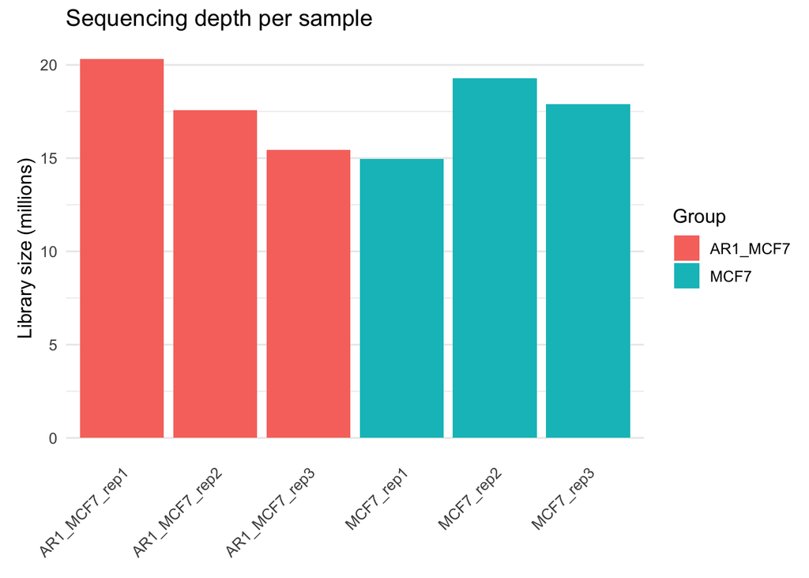

```r
libsize_df <- data.frame(sample   = factor(colnames(dge), levels = colnames(dge)),
                          lib_size = dge$samples$lib.size / 1e6,
                          group    = metadata$group)

ggplot(libsize_df, aes(x = sample, y = lib_size, fill = group)) +
  geom_col() +
  labs(title = "Sequencing depth per sample", x = NULL,
       y = "Library size (millions)", fill = "Group") +
  theme_minimal(base_size = 12) +
  theme(axis.text.x = element_text(angle = 45, hjust = 1),
        panel.grid.major.x = element_blank(),
        plot.margin = margin(5.5, 5.5, 11, 11))
```

#### Filter out low-count genes

Genes with very few reads across all samples carry little statistical power and mostly add noise (and multiple-testing burden) to the analysis. edgeR’s `filterByExpr()` keeps genes with enough counts to be reliably tested in at least one group.

```r
keep <- filterByExpr(dge, group = metadata$group)
cat(sprintf("Keeping %d of %d genes\n", sum(keep), length(keep)))
```

```
## Keeping 12002 of 18637 genes
```

The density plot below compares log-CPM distributions before and after filtering – the discarded genes are the peak of near-zero-count genes on the far left.

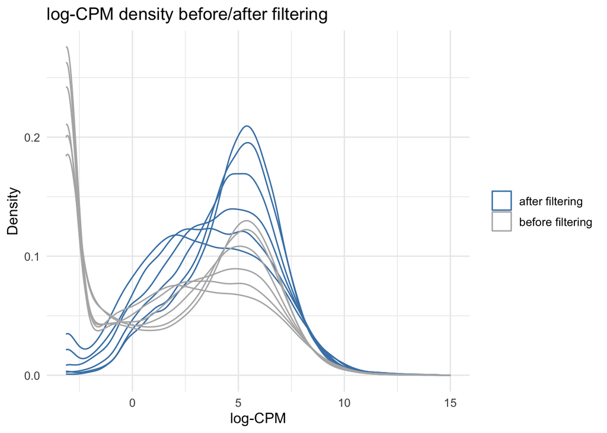

```r
logcpm_before <- edgeR::cpm(dge, log = TRUE)
logcpm_kept   <- logcpm_before[keep, , drop = FALSE]

density_df <- rbind(
  data.frame(logcpm = as.vector(logcpm_before), sample = rep(colnames(dge), each = nrow(logcpm_before)), set = "before filtering"),
  data.frame(logcpm = as.vector(logcpm_kept),   sample = rep(colnames(dge), each = nrow(logcpm_kept)),   set = "after filtering")
)

ggplot(density_df, aes(x = logcpm, group = interaction(sample, set), color = set)) +
  geom_density() +
  scale_color_manual(values = c("before filtering" = "grey70", "after filtering" = "steelblue")) +
  labs(title = "log-CPM density before/after filtering", x = "log-CPM", y = "Density", color = NULL) +
  theme_minimal(base_size = 12)
```

Apply the gene filter to the data

```r
dge <- dge[keep, , keep.lib.sizes = FALSE]
```

#### Normalize with TMM

Trimmed Mean of M-values (TMM) normalization corrects for differences in RNA composition between samples (not just sequencing depth), which keeps highly-expressed genes in one sample from skewing the comparison.

```r
dge <- calcNormFactors(dge, method = "TMM")
dge$samples
```

```
##                  group lib.size norm.factors
## AR1_MCF7_rep1 AR1_MCF7 20322901    0.7911958
## AR1_MCF7_rep2 AR1_MCF7 17563370    0.9545755
## AR1_MCF7_rep3 AR1_MCF7 15438539    0.6605437
## MCF7_rep1         MCF7 14947744    1.3274047
## MCF7_rep2         MCF7 19252623    1.1337132
## MCF7_rep3         MCF7 17890027    1.3319799
```

#### QC: MDS plot

A multidimensional scaling (MDS) plot is edgeR’s version of PCA – samples that are more similar in expression sit closer together. We expect replicates to cluster and the two groups to separate.

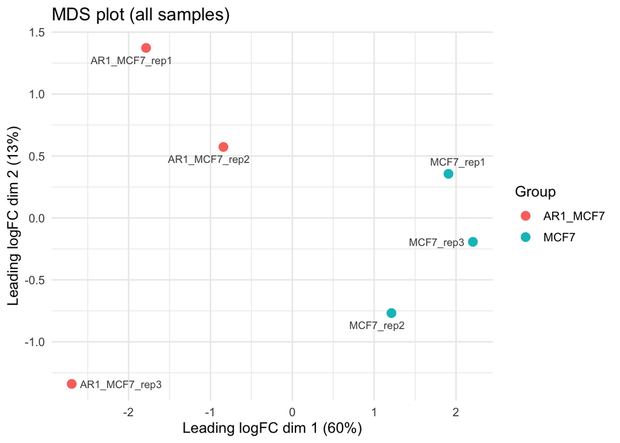

```r
mds <- plotMDS(dge, plot = FALSE)
var_pct <- round(100 * mds$var.explained[mds$dim.plot])
mds_df <- data.frame(dim1 = mds$x, dim2 = mds$y,
                      sample = colnames(dge), group = metadata$group)

ggplot(mds_df, aes(x = dim1, y = dim2, color = group)) +
  geom_point(size = 3) +
  ggrepel::geom_text_repel(aes(label = sample), size = 3, color = "grey30",
                            show.legend = FALSE, max.overlaps = Inf,
                            box.padding = 0.4, segment.color = "grey60") +
  labs(title = "MDS plot (all samples)",
       x = sprintf("Leading logFC dim %d (%d%%)", mds$dim.plot[1], var_pct[1]),
       y = sprintf("Leading logFC dim %d (%d%%)", mds$dim.plot[2], var_pct[2]),
       color = "Group") +
  theme_minimal(base_size = 12) +
  theme(legend.position = "right")
```

#### Design matrix and dispersion estimation

We build one design matrix for the two groups and estimate dispersion using all 6 samples together, which gives a more stable estimate than fitting each sample individually.

```r
design <- model.matrix(~0 + group, data = metadata)
colnames(design) <- levels(metadata$group)

design
```

```
##   AR1_MCF7 MCF7
## 1        1    0
## 2        1    0
## 3        1    0
## 4        0    1
## 5        0    1
## 6        0    1
## attr(,"assign")
## [1] 1 1
## attr(,"contrasts")
## attr(,"contrasts")$group
## [1] "contr.treatment"
```

```r
dge <- estimateDisp(dge, design, robust = TRUE)
cat(sprintf("Common dispersion: %.4f (BCV = %.3f)\n",
            dge$common.dispersion, sqrt(dge$common.dispersion)))
```

```
## Common dispersion: 0.1539 (BCV = 0.392)
```

The biological coefficient of variation (BCV) plot shows how variance (dispersion) changes with expression level – lowly-expressed genes are typically noisier (higher BCV).

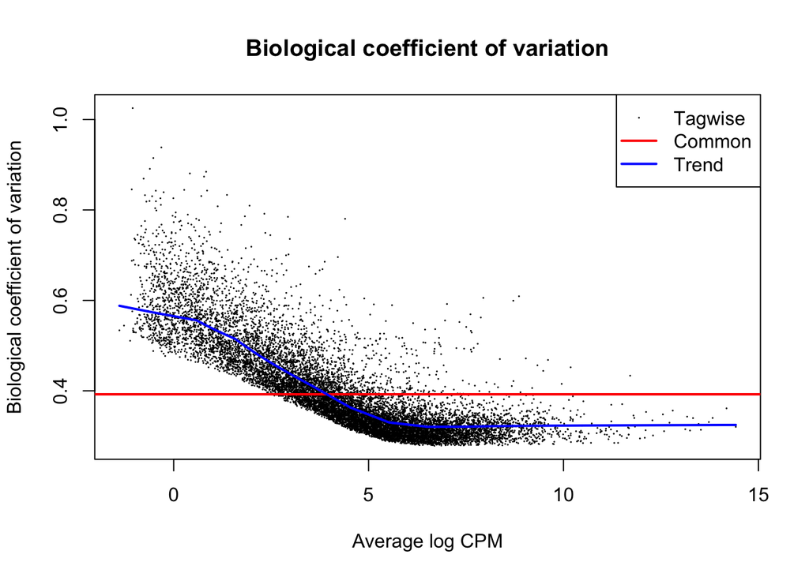

```r
plotBCV(dge, main = "Biological coefficient of variation")
```

#### Fit the model and define contrasts

We use a quasi-likelihood (QL) F-test (`glmQLFit`/`glmQLFTest`), which is recommended by edgeR for bulk RNA-seq as it accounts for uncertainty in the dispersion estimate and gives more robust error control than the classic likelihood-ratio test.

```r
fit <- glmQLFit(dge, design, robust = TRUE)
```

A contrast is defined as `pos - neg`, so a **positive logFC means higher expression in `pos`**, and a negative logFC means higher expression in `neg`. We keep track of that mapping so the volcano plot can label the axis accordingly.

```r
contrasts <- makeContrasts(
  AR1_vs_MCF7 = AR1_MCF7 - MCF7,
  levels = design
)

contrast_groups <- list(
  AR1_vs_MCF7 = c(pos = "AR1_MCF7", neg = "MCF7")
)

contrast_groups
```

```
## $AR1_vs_MCF7
##        pos        neg
## "AR1_MCF7"     "MCF7"
```

#### Visualization

Helper functions for visualization

The same steps can be reused for any contrast (you can run a different one yourself on the practice dataset at the end), we define one function that runs the test, tables, and plots for a given contrast, and one helper that picks which genes to label on the volcano plot.

Genes are ranked by a blend of significance (FDR) and effect size (|log2FC|), so the labeled genes are both strongly *and* significantly changed rather than just the single most extreme metric; up to 15 genes are labeled on each side (Up / Down).

```r
top_labels <- function(df, n = 15) {
  if (nrow(df) == 0) return(character(0))
  combined_rank <- rank(df$FDR, ties.method = "average") +
    rank(-abs(df$logFC), ties.method = "average")
  df$gene[order(combined_rank)][seq_len(min(n, nrow(df)))]
}

run_contrast <- function(contrast_name) {
  qlf <- glmQLFTest(fit, contrast = contrasts[, contrast_name])

  ## adjust.method = "BH" (Benjamini-Hochberg) controls the false discovery
  ## rate across all genes tested; it is edgeR's default, spelled out here
  ## since the FDR column drives both the significance calls and the
  ## volcano plot's y-axis.
  tt <- topTags(qlf, n = Inf, sort.by = "PValue", adjust.method = "BH")$table
  tt$gene <- rownames(tt)
  tt <- tt[, c("gene", setdiff(colnames(tt), "gene"))]

  fdr_cutoff <- 0.05
  fc_cutoff  <- 1
  pos_group  <- contrast_groups[[contrast_name]][["pos"]]
  neg_group  <- contrast_groups[[contrast_name]][["neg"]]

  tt$negLog10FDR <- -log10(pmax(tt$FDR, 1e-300))
  tt$status <- "Not sig."
  tt$status[tt$FDR < fdr_cutoff & tt$logFC >=  fc_cutoff] <- "Up"
  tt$status[tt$FDR < fdr_cutoff & tt$logFC <= -fc_cutoff] <- "Down"
  tt$status <- factor(tt$status, levels = c("Down", "Not sig.", "Up"))

  list(qlf = qlf, table = tt, pos = pos_group, neg = neg_group,
       fdr_cutoff = fdr_cutoff, fc_cutoff = fc_cutoff)
}

plot_ma <- function(result, contrast_name) {
  plotMD(result$qlf, main = sprintf("MA plot: %s", contrast_name))
  abline(h = 0, col = "grey40")
}

plot_volcano <- function(result, contrast_name) {
  tt <- result$table
  up_labels   <- top_labels(tt[tt$status == "Up", ],   n = 15)
  down_labels <- top_labels(tt[tt$status == "Down", ], n = 15)
  tt$label <- ifelse(tt$gene %in% c(up_labels, down_labels), tt$gene, NA)

  n_up   <- sum(tt$status == "Up")
  n_down <- sum(tt$status == "Down")
  x_range <- range(tt$logFC, na.rm = TRUE)
  y_min   <- min(tt$negLog10FDR, na.rm = TRUE)

  ggplot(tt, aes(x = logFC, y = negLog10FDR, color = status)) +
    geom_point(alpha = 0.6, size = 1.4) +
    geom_vline(xintercept = c(-result$fc_cutoff, result$fc_cutoff), linetype = "dashed", color = "grey50") +
    geom_hline(yintercept = -log10(result$fdr_cutoff), linetype = "dashed", color = "grey50") +
    ggrepel::geom_text_repel(aes(label = label), color = "black", size = 3,
                              max.overlaps = Inf, min.segment.length = 0,
                              box.padding = 0.4, segment.color = "grey40",
                              na.rm = TRUE, show.legend = FALSE) +
    scale_color_manual(values = c("Down" = "#0072B2", "Not sig." = "grey80", "Up" = "#D55E00"),
                        drop = FALSE) +
    annotate("text", x = x_range[1], y = y_min, label = paste("<- higher in", result$neg),
             hjust = 0, vjust = 1.5, size = 3, color = "grey40", fontface = "italic") +
    annotate("text", x = x_range[2], y = y_min, label = paste("higher in", result$pos, "->"),
             hjust = 1, vjust = 1.5, size = 3, color = "grey40", fontface = "italic") +
    labs(title = sprintf("Volcano plot: %s", contrast_name),
         subtitle = sprintf("%d up / %d down (BH FDR < %.2f, |log2FC| >= %g); labeled: up to 15 per side (FDR + |FC|)",
                             n_up, n_down, result$fdr_cutoff, result$fc_cutoff),
         x = sprintf("log2 fold-change (%s vs %s)", result$pos, result$neg),
         y = "-log10(FDR, BH-adjusted)",
         color = NULL) +
    coord_cartesian(clip = "off") +
    theme_minimal(base_size = 12) +
    theme(plot.title = element_text(face = "bold"),
          plot.subtitle = element_text(color = "grey30", size = 9),
          panel.grid.minor = element_blank(),
          legend.position = "top",
          plot.margin = margin(5.5, 5.5, 11, 5.5))
}
```

#### AR1_MCF7 vs MCF7

In the following steps we will use the helper functions to run the differential analysis and visualize results.

Compare Abemaciclib resistant MCF7 cells to the parental MCF7 samples.

```r
res_ar1 <- run_contrast("AR1_vs_MCF7")

# write results table
write.table(res_ar1$qlf, "AR1_vs_MCF7.txt", sep = '\t')

# View summary
summary(decideTests(res_ar1$qlf))
```

```
##        1*AR1_MCF7 -1*MCF7
## Down                 3737
## NotSig               5317
## Up                   2948
```

Create mean-difference plot (aka MA plot) which shows log fold-changes on the y-axis against average expression on the x-axis, and colour highlights differentially expressed genes in a fitted model.

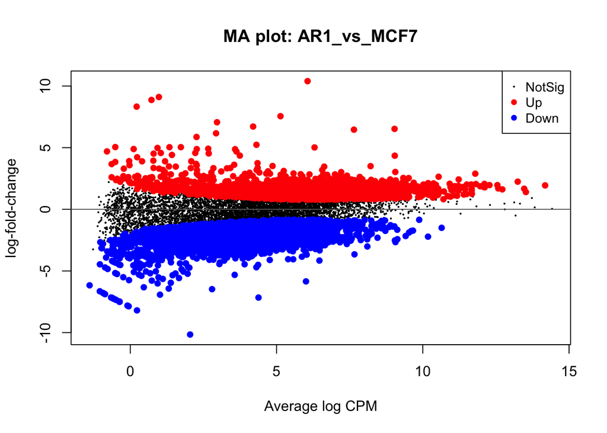

```r
plot_ma(res_ar1, "AR1_vs_MCF7")
```

Generate the volcano plot, colour and label the differentially expressed genes.

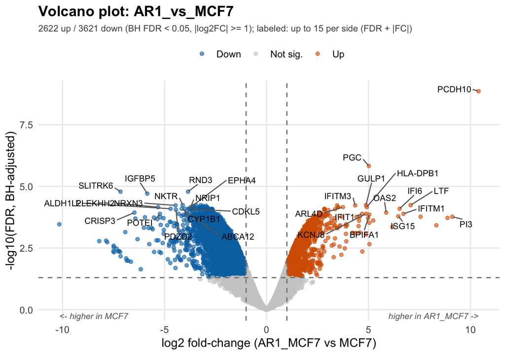

```r
plot_volcano(res_ar1, "AR1_vs_MCF7")
```

Explore the complete table of DE results

```r
DT::datatable(res_ar1$table[, c("gene", "logFC", "logCPM", "PValue", "FDR")],
              rownames = FALSE, filter = "top",
              options = list(pageLength = 10)) |>
  DT::formatSignif(columns = c("logFC", "logCPM", "PValue", "FDR"), digits = 3)
```

| gene | logFC | logCPM | PValue | FDR |
| --- | --- | --- | --- | --- |
| PCDH10 | 10.39560115377204 | 6.059651464069955 | 1.161922679009883e-13 | 1.394539599347662e-09 |
| PGC | 5.018901792054246 | 6.298216786030782 | 2.484624124207451e-10 | 1.491022936936891e-06 |
| SLITRK6 | -7.158507552435842 | 4.382804461226645 | 4.651976202610677e-09 | 1.640344517157728e-05 |
| RND3 | -3.844851895253296 | 5.866929522669171 | 5.466903906541336e-09 | 1.640344517157728e-05 |
| IGFBP5 | -5.845983069183572 | 6.005742688903574 | 8.197923012152533e-09 | 1.967829439837094e-05 |
| LTF | 7.063581932497137 | 2.963987405298558 | 3.895887340421733e-08 | 5.777984714796674e-05 |
| GPD2 | -3.457962734476127 | 5.993681989935097 | 4.089363750847006e-08 | 5.777984714796674e-05 |
| CLIP1 | -3.223794027019878 | 6.330449678635093 | 4.254410447372756e-08 | 5.777984714796674e-05 |
| NKTR | -4.108657511438241 | 4.76797615194538 | 4.774219551128341e-08 | 5.777984714796674e-05 |
| GULP1 | 4.875668776230094 | 3.5818832176857 | 4.814184898180865e-08 | 5.777984714796674e-05 |

[output cut: 11992 more lines]

For practice, you can copy/download the practice data from `~/CourseData/Module6/practice/expression/practice_expression_data.txt` and `~/CourseData/Module6/practice/expression/practice_sample_metadata.txt` and make the changes in this script for differential expression analysis between the two drug resistant cell groups, Abemaciclib-resistant (AR_MCF7) vs. Palbociclib-resistant (PR_MCF7)

**Show Hints**

*Hints:*

- add the respective file paths to the above R script
- pay attention to the new `design` matrix generated with the sample metadata
- make changes to the `contrasts` and `contrast_groups` using the sample names from `design`
- helper functions remain the same
- run the final steps with the new contrasts for PR vs AR sample groups